> **Tip**: Welcome to the Investigate a Dataset project! You will find tips in quoted sections like this to help organize your approach to your investigation. Once you complete this project, remove these **Tip** sections from your report before submission. First things first, you might want to double-click this Markdown cell and change the title so that it reflects your dataset and investigation.

# Investigate a Dataset - [noshowappointments-kagglev2-may-2016.csv]

- Introduction
- Data Wrangling
- Exploratory Data Analysis
- Conclusions

## Introduction

This dataset collects information from 100k medical appointments in Brazil and is focused on the question of whether or not patients show up for their appointment. A number of characteristics about the patient are included in each row. ● ‘ScheduledDay’ tells us on what day the patient set up their appointment. ● ‘Neighborhood’ indicates the location of the hospital. ● ‘Scholarship’ indicates whether or not the patient is enrolled in Brasilian welfare program Bolsa Família. ● Be careful about the encoding of the last column: it says ‘No’ if the patient showed up to their appointment, and ‘Yes’ if they did not show up.

### Dataset Description

We have csv file contain the data we are going to analyis it

### Question(s) for Analysis

> **Tip**: Clearly state one or more questions that you plan on exploring over the course of the report. You will address these questions in the **data analysis** and **conclusion** sections. Try to build your report around the analysis of at least one dependent variable and three independent variables. If you're not sure what questions to ask, then make sure you familiarize yourself with the dataset, its variables and the dataset context for ideas of what to explore.

> **Tip**: Once you start coding, use NumPy arrays, Pandas Series, and DataFrames where appropriate rather than Python lists and dictionaries. Also, **use good coding practices**, such as, define and use functions to avoid repetitive code. Use appropriate comments within the code cells, explanation in the mark-down cells, and meaningful variable names.

```python
# Use this cell to set up import statements for all of the packages that you
#   plan to use.

# Remember to include a 'magic word' so that your visualizations are plotted
#   inline with the notebook. See this page for more:
#   http://ipython.readthedocs.io/en/stable/interactive/magics.html
import pandas as pd
import numpy as np
import matplotlib.pyplot as plt
import seaborn as sns
% matplotlib inline
```

```python
# Upgrade pandas to use dataframe.explode() function.
!pip install --upgrade pandas==0.25.0
```

## Data Wrangling

> **Tip**: In this section of the report, you will load in the data, check for cleanliness, and then trim and clean your dataset for analysis. Make sure that you **document your data cleaning steps in mark-down cells precisely and justify your cleaning decisions.**

### General Properties

> **Tip**: You should *not* perform too many operations in each cell. Create cells freely to explore your data. One option that you can take with this project is to do a lot of explorations in an initial notebook. These don't have to be organized, but make sure you use enough comments to understand the purpose of each code cell. Then, after you're done with your analysis, create a duplicate notebook where you will trim the excess and organize your steps so that you have a flowing, cohesive report.

```python
# Load your data and print out a few lines. Perform operations to inspect data
#   types and look for instances of missing or possibly errant data.
effect=pd.read_csv('noshowappointments-kagglev2-may-2016.csv')
effect.head()
```

|  | PatientId | AppointmentID | Gender | ScheduledDay | AppointmentDay | Age | Neighbourhood | Scholarship | Hipertension | Diabetes | Alcoholism | Handcap | SMS_received | No-show |
| --- | --- | --- | --- | --- | --- | --- | --- | --- | --- | --- | --- | --- | --- | --- |
| 0 | 2.987250e+13 | 5642903 | F | 2016-04-29T18:38:08Z | 2016-04-29T00:00:00Z | 62 | JARDIM DA PENHA | 0 | 1 | 0 | 0 | 0 | 0 | No |
| 1 | 5.589978e+14 | 5642503 | M | 2016-04-29T16:08:27Z | 2016-04-29T00:00:00Z | 56 | JARDIM DA PENHA | 0 | 0 | 0 | 0 | 0 | 0 | No |
| 2 | 4.262962e+12 | 5642549 | F | 2016-04-29T16:19:04Z | 2016-04-29T00:00:00Z | 62 | MATA DA PRAIA | 0 | 0 | 0 | 0 | 0 | 0 | No |
| 3 | 8.679512e+11 | 5642828 | F | 2016-04-29T17:29:31Z | 2016-04-29T00:00:00Z | 8 | PONTAL DE CAMBURI | 0 | 0 | 0 | 0 | 0 | 0 | No |
| 4 | 8.841186e+12 | 5642494 | F | 2016-04-29T16:07:23Z | 2016-04-29T00:00:00Z | 56 | JARDIM DA PENHA | 0 | 1 | 1 | 0 | 0 | 0 | No |

```python
effect.shape
```

```
(110527, 14)
```

```python
effect.info()
```

```
<class 'pandas.core.frame.DataFrame'>
RangeIndex: 110527 entries, 0 to 110526
Data columns (total 14 columns):
PatientId         110527 non-null float64
AppointmentID     110527 non-null int64
Gender            110527 non-null object
ScheduledDay      110527 non-null object
AppointmentDay    110527 non-null object
Age               110527 non-null int64
Neighbourhood     110527 non-null object
Scholarship       110527 non-null int64
Hipertension      110527 non-null int64
Diabetes          110527 non-null int64
Alcoholism        110527 non-null int64
Handcap           110527 non-null int64
SMS_received      110527 non-null int64
No-show           110527 non-null object
dtypes: float64(1), int64(8), object(5)
memory usage: 11.8+ MB
```

There is No Null Values in Dataset

```python
effect.describe()
```

|  | PatientId | AppointmentID | Age | Scholarship | Hipertension | Diabetes | Alcoholism | Handcap | SMS_received |
| --- | --- | --- | --- | --- | --- | --- | --- | --- | --- |
| count | 1.105270e+05 | 1.105270e+05 | 110527.000000 | 110527.000000 | 110527.000000 | 110527.000000 | 110527.000000 | 110527.000000 | 110527.000000 |
| mean | 1.474963e+14 | 5.675305e+06 | 37.088874 | 0.098266 | 0.197246 | 0.071865 | 0.030400 | 0.022248 | 0.321026 |
| std | 2.560949e+14 | 7.129575e+04 | 23.110205 | 0.297675 | 0.397921 | 0.258265 | 0.171686 | 0.161543 | 0.466873 |
| min | 3.921784e+04 | 5.030230e+06 | -1.000000 | 0.000000 | 0.000000 | 0.000000 | 0.000000 | 0.000000 | 0.000000 |
| 25% | 4.172614e+12 | 5.640286e+06 | 18.000000 | 0.000000 | 0.000000 | 0.000000 | 0.000000 | 0.000000 | 0.000000 |
| 50% | 3.173184e+13 | 5.680573e+06 | 37.000000 | 0.000000 | 0.000000 | 0.000000 | 0.000000 | 0.000000 | 0.000000 |
| 75% | 9.439172e+13 | 5.725524e+06 | 55.000000 | 0.000000 | 0.000000 | 0.000000 | 0.000000 | 0.000000 | 1.000000 |
| max | 9.999816e+14 | 5.790484e+06 | 115.000000 | 1.000000 | 1.000000 | 1.000000 | 1.000000 | 4.000000 | 1.000000 |

```python
effect.duplicated().sum()
```

```
0
```

```python
effect['PatientId'].duplicated().sum()
```

```
48228
```

```python
#check for the unique Patient
effect['PatientId'].nunique()
```

```
62299
```

i have only 62299 patient

```python
# the number of the unique values for each column
col = list(effect.columns.values)
for X in col:
    unique = effect[X].nunique()
    print( "Number of unique values in {} is :".format(X) ,unique)
```

```
Number of unique values in PatientId is : 62299
Number of unique values in AppointmentID is : 110527
Number of unique values in Gender is : 2
Number of unique values in ScheduledDay is : 103549
Number of unique values in AppointmentDay is : 27
Number of unique values in Age is : 104
Number of unique values in Neighbourhood is : 81
Number of unique values in Scholarship is : 2
Number of unique values in Hipertension is : 2
Number of unique values in Diabetes is : 2
Number of unique values in Alcoholism is : 2
Number of unique values in Handcap is : 5
Number of unique values in SMS_received is : 2
Number of unique values in No-show is : 2
```

```python
# what is the unique values for some columns
col = list(effect.columns.values)
for Y in col:
    if Y not in ['PatientId', 'AppointmentID','Age', 'ScheduledDay', 'AppointmentDay', 'Neighbourhood']:
        unique_val = effect[Y].unique()
        print( "Number of unique values in {} is :".format(Y) ,unique_val)
```

```
Number of unique values in Gender is : ['F' 'M']
Number of unique values in Scholarship is : [0 1]
Number of unique values in Hipertension is : [1 0]
Number of unique values in Diabetes is : [0 1]
Number of unique values in Alcoholism is : [0 1]
Number of unique values in Handcap is : [0 1 2 3 4]
Number of unique values in SMS_received is : [0 1]
Number of unique values in No-show is : ['No' 'Yes']
```

### Data Cleaning

After Discussing the Structure of the data and any problems then need to be cleaned , perform those cleaning Steps in Second part of this section

```python
effect.drop(['PatientId', 'AppointmentID', 'ScheduledDay', 'AppointmentDay'], axis=1, inplace=True)
effect.rename( columns={'No-show':'No_show'}, inplace=True)
effect.rename( columns={'Hipertension':'Hypertension'}, inplace=True)


effect.head()
```

|  | Gender | Age | Neighbourhood | Scholarship | Hypertension | Diabetes | Alcoholism | Handcap | SMS_received | No_show |
| --- | --- | --- | --- | --- | --- | --- | --- | --- | --- | --- |
| 0 | F | 62 | JARDIM DA PENHA | 0 | 1 | 0 | 0 | 0 | 0 | No |
| 1 | M | 56 | JARDIM DA PENHA | 0 | 0 | 0 | 0 | 0 | 0 | No |
| 2 | F | 62 | MATA DA PRAIA | 0 | 0 | 0 | 0 | 0 | 0 | No |
| 3 | F | 8 | PONTAL DE CAMBURI | 0 | 0 | 0 | 0 | 0 | 0 | No |
| 4 | F | 56 | JARDIM DA PENHA | 0 | 1 | 1 | 0 | 0 | 0 | No |

```python
# Age looks weird
len(effect[effect["Age"] == 0]),len(effect[effect["Age"] < 0])
```

```
(3539, 1)
```

```python
#find patient whoes age=-1
wiredpatient=effect.query('Age==-1')
wiredpatient
```

|  | Gender | Age | Neighbourhood | Scholarship | Hypertension | Diabetes | Alcoholism | Handcap | SMS_received | No_show |
| --- | --- | --- | --- | --- | --- | --- | --- | --- | --- | --- |
| 99832 | F | -1 | ROMÃO | 0 | 0 | 0 | 0 | 0 | 0 | No |

```python
#drop this patientand remain Age=0 as akids
effect.drop(index=99832, inplace=True)
```

now we drop this invalid row

## Exploratory Data Analysis

> **Tip**: we've trimmed and cleaned the data, we're ready to move on to exploration. Compute statistics and create visualizations with the goal of addressing the research questions that you posed in the Introduction section

### Generallook on Data

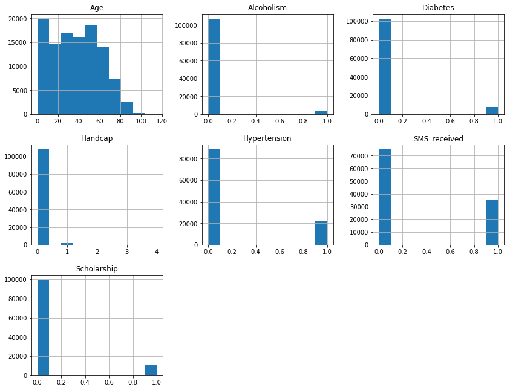

```python
# Use this, and more code cells, to explore your data. Don't forget to add
#   Markdown cells to document your observations and findings.
effect.hist(figsize=(14,11));
```

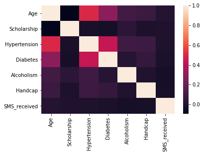

```python
# Generating the correlation heatmap to compare the correlation between features
correlation = effect.corr()
sns.heatmap(correlation);
```

there's no need to remove any feature

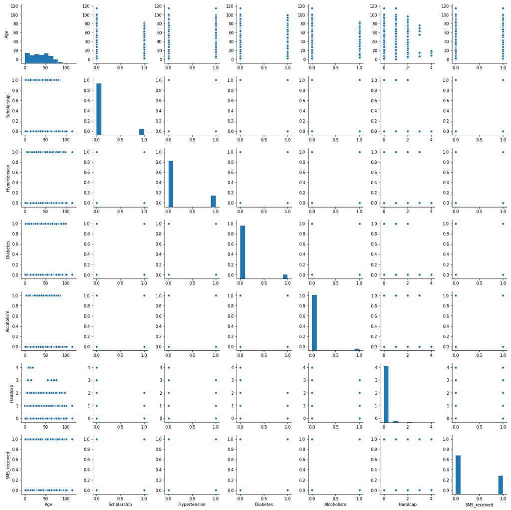

```python
#Draw pairplot kind scatter
sns.pairplot(effect, kind="scatter")
plt.show()
```

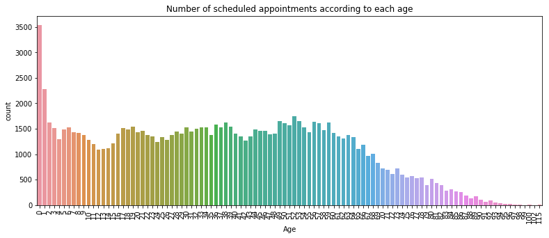

```python
# Number of patients at each age
plt.figure(figsize=(13,5))
plt.xticks(rotation=90)
xP = sns.countplot(x=effect.Age)
xP.set_title("Number of scheduled appointments according to each age")
plt.show()
```

we can see that the most of appointmenst in age (0 and 1) and also alot in range (49 to 59)

```python
Show = effect.No_show== 'No'
NO_show =effect.No_show== 'Yes'
```

```python
effect[Show].count()
```

```
Gender           88207
Age              88207
Neighbourhood    88207
Scholarship      88207
Hypertension     88207
Diabetes         88207
Alcoholism       88207
Handcap          88207
SMS_received     88207
No_show          88207
dtype: int64
```

```python
effect[NO_show ].count()
```

```
Gender           22319
Age              22319
Neighbourhood    22319
Scholarship      22319
Hypertension     22319
Diabetes         22319
Alcoholism       22319
Handcap          22319
SMS_received     22319
No_show          22319
dtype: int64
```

## Investigate other factore affect on coming of patient

# Research Question1

What are the important factors for us to know if the patient will come on time?

```python
effect[Show].groupby(['Hypertension','Diabetes']).mean()['Age']
effect[NO_show].groupby(['Hypertension','Diabetes']).mean()['Age']
```

```
Hypertension  Diabetes
0             0           28.834155
              1           49.183391
1             0           58.377043
              1           62.820333
Name: Age, dtype: float64
```

```python
#values count of All attendance
effect["No_show"].value_counts()
```

```
No     88207
Yes    22319
Name: No_show, dtype: int64
```

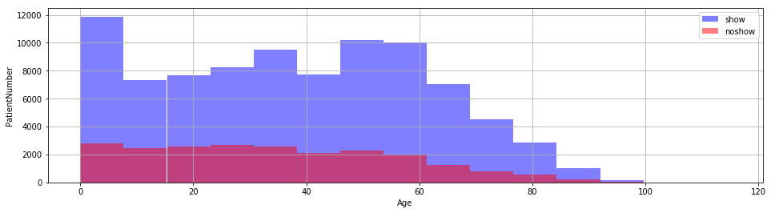

```python
#dos age of patient affect on attendance
def attendance (effect,col_name, attend, absent):
    plt.figure(figsize=[16,4]);
    effect[col_name][Show].hist(alpha=0.5,bins=15,color='blue',label='show')
    effect[col_name][NO_show].hist(alpha=0.5,bins=15,color='red',label='noshow')
    plt.legend();
    plt.xlabel('Age')
    plt.ylabel('PatientNumber');
attendance(effect,'Age', show, noshow)
```

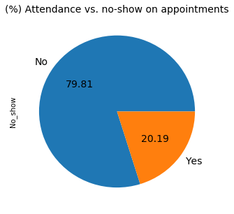

```python
#represet the attendance percentage with pie chart
plt.title ("(%) Attendance vs. no-show on appointments", fontsize=14)
effect["No_show"].value_counts().plot(figsize=(5,5),kind="pie",autopct='%.2f', textprops={'fontsize': 14});
```

[output not shown]

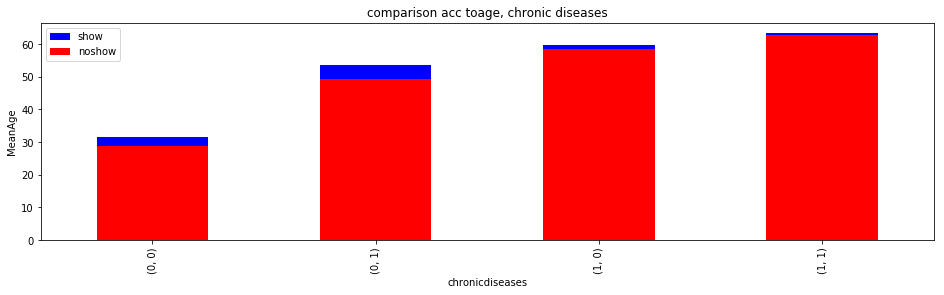

```python
#doesageand chornic diseases are affected on the attendance rat together
plt.figure(figsize=[16,4]);
effect[Show].groupby(['Hypertension','Diabetes']).mean()['Age'].plot(kind='bar',color='blue',label='show')

effect[NO_show].groupby(['Hypertension','Diabetes']).mean()['Age'].plot(kind='bar',color='red',label='noshow')

plt.legend()
plt.title('comparison acc toage, chronic diseases')
plt.xlabel('chronicdiseases')
plt.ylabel('MeanAge')
```

```python
# check the value count of all attendance
effect["Gender"].value_counts()
```

```
F    71839
M    38687
Name: Gender, dtype: int64
```

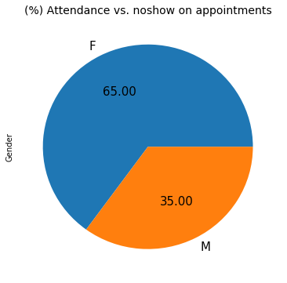

```python
#represet the attendance percentage with pie chart
plt.title ("(%) Attendance vs. noshow on appointments", fontsize=14)
effect["Gender"].value_counts().plot(figsize=(6,6),kind="pie",autopct='%.2f', textprops={'fontsize': 15});
```

[output not shown]

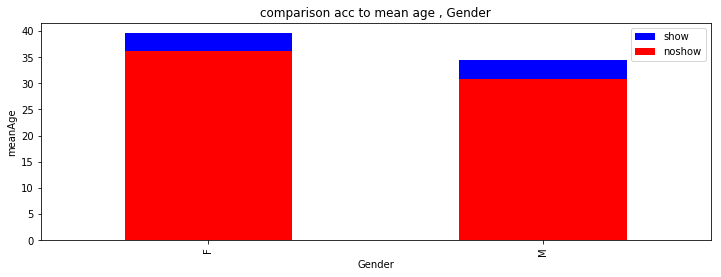

```python
#does  age and Gender affect on the attendance together( check by meean age)
plt.figure(figsize=[12,4]);
effect[Show].groupby('Gender').Age.mean().plot(kind='bar',color='blue',label='show')
effect[NO_show].groupby('Gender').Age.mean().plot(kind='bar',color='red',label='noshow')
plt.legend()
plt.title('comparison acc to mean age , Gender')
plt.xlabel('Gender')
plt.ylabel('meanAge')
```

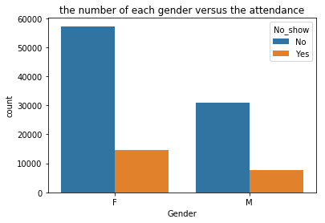

```python
#show the number of each gender versus the attendance by bar chart¶
Attends = effect['No_show']
show = sns.countplot(x=effect.Gender, hue=Attends)
show.set_title("the number of each gender versus the attendance")
x_ticks_labels=['F', 'M']
plt.show();
```

We notice that the number of Female patients is higher in both showing and not-showing, compared to the male patients, which is understandable , due to higher number of appointments for the females

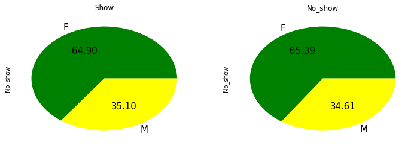

```python
#No-show percentage for female patients versus male patients
fig, axs = plt.subplots(1,2)
effect[effect["No_show"]=="No"].groupby("Gender")["No_show"].count().plot(figsize=(12,4),kind="pie",autopct='%.2f', ax=axs[0],colors=['green','yellow'],title="Show",textprops={'fontsize': 15});
effect[effect["No_show"]=="Yes"].groupby("Gender")["No_show"].count().plot(figsize=(12,4),kind="pie",autopct='%.2f',ax=axs[1],colors=['green','yellow'],title="No_show", textprops={'fontsize': 15});
```

```python
# check the count of appointments for different ages
effect["Age"].value_counts()
```

```
0      3539
1      2273
52     1746
49     1652
53     1651
       ...
98        6
115       5
100       4
102       2
99        1
Name: Age, Length: 103, dtype: int64
```

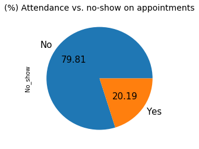

```python
#represet the attendance percentage with pie chart
plt.title ("(%) Attendance vs. no-show on appointments", fontsize=14)
effect["No_show"].value_counts().plot(figsize=(4,4),kind="pie",autopct='%.2f', textprops={'fontsize': 15});
```

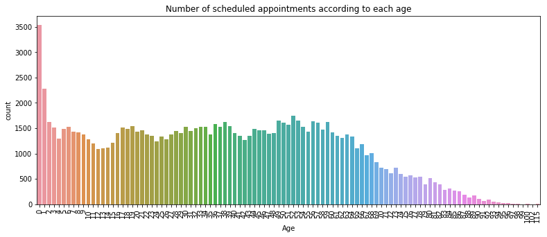

```python
# Number of patients at each age
plt.figure(figsize=(13,5))
plt.xticks(rotation=90)
xP = sns.countplot(x=effect.Age)
xP.set_title("Number of scheduled appointments according to each age")
plt.show()
```

we can see that the most of appointmenst in age (0 and 1) and also alot in range (49 to 59)

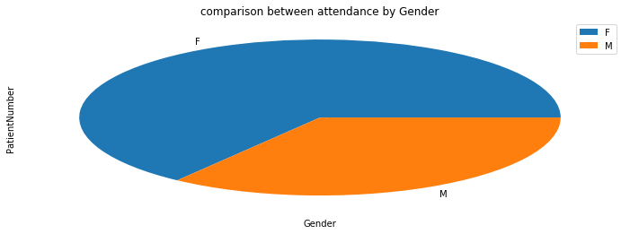

```python
#the precentage of sex influance
def attendance(effect, col_name,attend,absent):
    plt.figure(figsize=[12,4])
    effect[col_name][Show].value_counts(normalize=True).plot(kind='pie',label='show')
    plt.legend();
    plt.title('comparison between attendance by Gender')
    plt.xlabel("Gender")
    plt.ylabel('PatientNumber');
attendance(effect,'Gender',show,noshow)
```

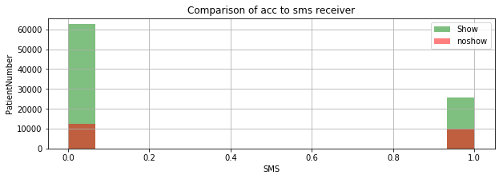

```python
#does receving SMS  affect attendance
def attend (effect,colname,attend, absent):
    plt.figure(figsize=[10,3]);
    effect[colname][Show].hist(alpha =0.5,bins=15, color='green',label='Show')
    effect[colname][NO_show].hist(alpha =0.5, bins=15 ,color='red', label='noshow')
    plt.legend();
    plt.title('Comparison of acc to sms receiver')
    plt.xlabel('SMS')
    plt.ylabel('PatientNumber');
attend(effect,'SMS_received', Show, NO_show)
```

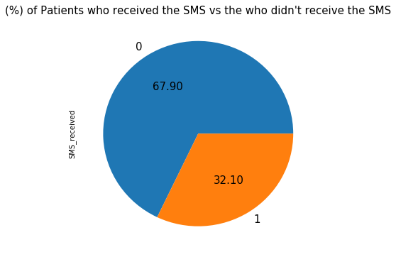

```python
#represet the SMS_received percentage with pie chart
plt.title ("(%) of Patients who received the SMS vs the who didn't receive the SMS", fontsize=15)
effect["SMS_received"].value_counts().plot(figsize=(6,6),kind="pie",autopct='%.2f', textprops={'fontsize': 15});
```

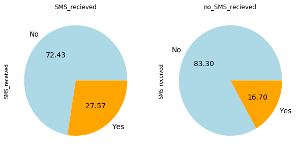

```python
# the precentage of the patients that recieved and show or no show up vs they don't
# the precentage of the patients that recieved and show or no show up vs they don't
fig, axs = plt.subplots(1,2)
effect[effect["SMS_received"]==1].groupby("No_show")["SMS_received"].count().plot(figsize=(10,5),kind="pie",autopct='%.2f', ax=axs[0],colors=['lightblue','orange'],title="SMS_recieved",textprops={'fontsize': 14});
effect[effect["SMS_received"]==0].groupby("No_show")["SMS_received"].count().plot(figsize=(10,5),kind="pie",autopct='%.2f',ax=axs[1],colors=['lightblue','orange'],title="no_SMS_recieved",textprops={'fontsize': 14});
```

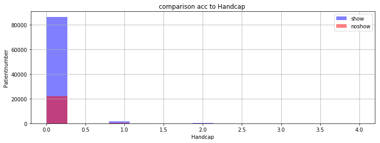

```python
#deos the Handcap affect the attendance
def attendance (effect ,colname, attend,absent):
    plt.figure(figsize=[12,4]);
    effect[colname][Show].hist(alpha=0.5,bins=15,color='blue',label='show')
    effect[colname][NO_show].hist(alpha=0.5,bins=15,color='red',label='noshow')
    plt.legend();
    plt.title('comparison acc to Handcap ')
    plt.xlabel('Handcap')
    plt.ylabel('Patientnumber');
attendance(effect,'Handcap',show,noshow)
```

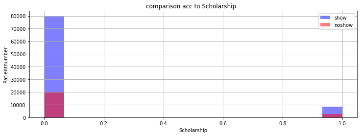

```python
#dose Scholarship affect on attendance
def attendance (effect ,colname, attend,absent):
    plt.figure(figsize=[12,4]);
    effect[colname][Show].hist(alpha=0.5,bins=15,color='blue',label='show')
    effect[colname][NO_show].hist(alpha=0.5,bins=15,color='red',label='noshow')
    plt.legend();
    plt.title('comparison acc to Scholarship  ')
    plt.xlabel('Scholarship')
    plt.ylabel('Patientnumber');
attendance(effect,'Scholarship',show,noshow)
```

## Conclusions

the Age has its role as thosein the 0-10age group were the most show up .followed by the age group 36-70

number of showing patient without receiving SMS is greater than number of showing with receiving SMS

The total number of patients who attended is more than those who did not attend, and the number of patients who did not attend was 20.19%

Patients who do not have a scholarship are more committed to attending appointments than patients who have a scholarship

> **Tip**: If you haven't done any statistical tests, do not imply any statistical conclusions. And make sure you avoid implying causation from correlation!

### Limitations

> **Tip**: Once you are satisfied with your work here, check over your report to make sure that it is satisfies all the areas of the rubric (found on the project submission page at the end of the lesson). You should also probably remove all of the "Tips" like this one so that the presentation is as polished as possible.

## Submitting your Project

> **Tip**: Before you submit your project, you need to create a .html or .pdf version of this notebook in the workspace here. To do that, run the code cell below. If it worked correctly, you should get a return code of 0, and you should see the generated .html file in the workspace directory (click on the orange Jupyter icon in the upper left).

> **Tip**: Alternatively, you can download this report as .html via the **File** > **Download as** submenu, and then manually upload it into the workspace directory by clicking on the orange Jupyter icon in the upper left, then using the Upload button.

> **Tip**: Once you've done this, you can submit your project by clicking on the "Submit Project" button in the lower right here. This will create and submit a zip file with this .ipynb doc and the .html or .pdf version you created. Congratulations!

```python
from subprocess import call
call(['python', '-m', 'nbconvert', 'Investigate_a_Dataset.ipynb'])
```

```
0
```